# Hazards

Hull breaches affect the ship’s oxygen supply. If it drops below a threshold value, units will begin to suffocate until they die. Fires are also affected by the oxygen drop.

We introduce chance parameters in the *Weapon* class to let us play with the likelihood they’ll start fires and damage the ship’s hull.

Fires can spread to adjacent tiles, including the neighboring rooms. In this demo, doors don’t prevent fire from spreading.

The following video should give you an idea of what we’ll make.

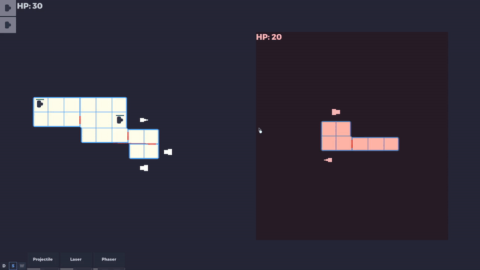

## The breach scene

Create a new scene file with a

[figure not shown]

`Sprite` as its root node. Rename the node to *Breach*. That’s the whole scene:

[figure not shown]

Select the

[figure not shown]

`Sprite` and start by adding `Assets.svg` to `Texture`.

Turn on *Region -> Enable* and set *Region -> Rect* to `Rect2(384, 384, 64, 64)` to get the right texture.

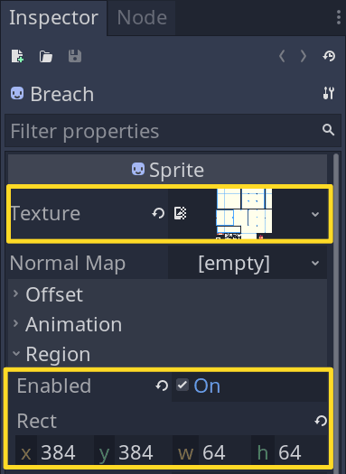

That’s all there is to this basic scene.

This is how the breach sprite looks in the 2D viewport:

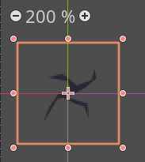

*Note* that I used the same color for the breach visuals as our project background. To showcase the result here, I reverted temporarily to the default background color.

Save your scene at `res://TacticalSpaceCombat/Ship/Hazards/Breach.tscn`.

Before diving into the code, let’s make the *Fire* scene.

Because the hazards inherit from the same parent class, we’ll tackle coding after making both scenes.

## The fire scene

Create a new inherited scene from *Breach* because we already set up some of the same properties on the sprite.

Rename the root node to *Fire* and continue by adding a

[figure not shown]

`Timer` and an

[figure not shown]

`AnimationPlayer`. We use the

[figure not shown]

`Timer` node to check for a chance that the fire will damage the ship and spread.

[figure not shown]

Change *Region -> Rect* to `Rect2(320, 384, 64, 64)` on the root node.

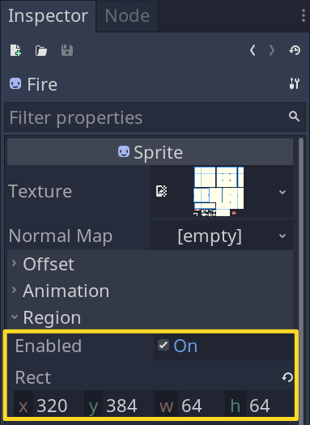

Select

[figure not shown]

`Timer` and set its *Wait Time* property to `0.5`, and turn on *Autostart*.

We use the

[figure not shown]

`Timer` node to create a similar functionality to the built-in `_process()` function, except it is called much less often.

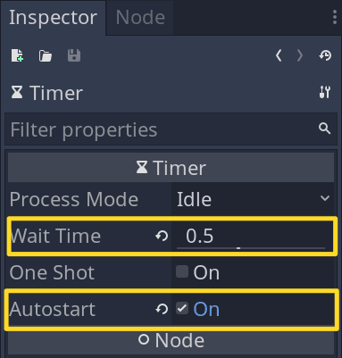

Units can move into rooms and extinguish fires.

We’ll have hitpoints to track the fire “health” status. This is reflected in the pulsating animation that we’ll work on next.

[figure not shown]

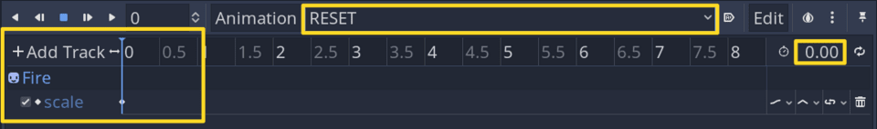

Create a new animation called `high`. This is the default animation when the fire has maximum hitpoints.

Set the animation length to `0.5`.

Record *Fire*’s *Scale* property with value `Vector2(1, 1)` at time `0`.

For the next keyframe, record it with value

[figure not shown]

`Vector2`(`0.8`, `0.8`) at time `0.4`.

Set the animation to autoplay on load and loop.

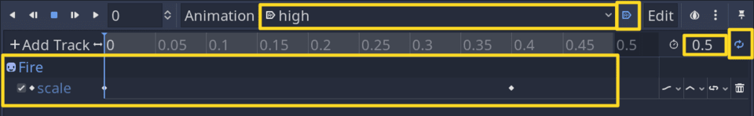

Select the first keyframe and set its *Easing* property to `-2`.

You can do so by double LMB, clicking on the curve and entering a numeric value, or by LMB and dragging left and right over the curve.

Alternatively, you can RMB click on the curve and select *In*-*Out* from the menu.

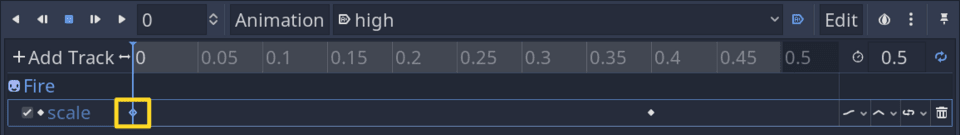

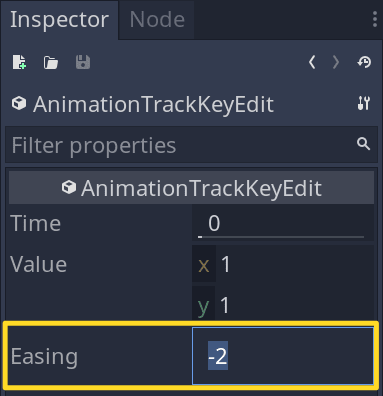

This will give us an animation that feels less mechanical than a linear easing.

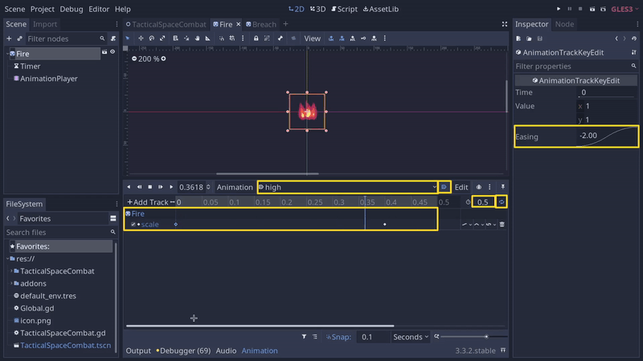

We have to create two more animations: `medium` and `low`.

Since we already made `high`, it’s best to duplicate it instead because the other animations are similar.

Rename the animation from `high (copy)` to `medium`.

Select the first keyframe and set its value to

[figure not shown]

`Vector2`(`0.8`, `0.8`) and set the second keyframe to

[figure not shown]

`Vector2`(`0.4`, `0.4`). Leave everything else unchanged.

Now, either duplicate `medium` or `high`. It doesn’t matter. Rename it to `low` and change the first keyframe to

[figure not shown]

`Vector2`(`0.4`, `0.4`) and the second one to

[figure not shown]

`Vector2`(`0.2`, `0.2`).

We have now finished setting up the *Fire* scene.

Save it at `res://TacticalSpaceCombat/Ship/Hazards/Fire.tscn`.

It’s time to code the hazards.

## Coding the hazards

Create a new empty script file at `res://TacticalSpaceCombat/Ship/Hazards/Hazard.gd`. Replace the template with this code:

```
class_name Hazard
extends Sprite

## Hitpoints threshold values to update the `Scale` property as the hazard takes
## damage from the units. The keys also correspond to the `Fire` animation
## names.
const THRESHOLD := {"medium": 70, "low": 30}

## Both `Breach` and `Fire` use the same `attack` variable but in different
## ways. `Breach` uses it to deplete the oxygen and `Fire` for damaging the
## units.
export (int) var attack := 10

var _hitpoints := 100 setget _set_hitpoints


func take_damage(value: int) -> void:
    _set_hitpoints(_hitpoints - value)


func _set_hitpoints(value: int) -> void:
    _hitpoints = value
    if _hitpoints <= 0:
        queue_free()
```

We set up for the hazards to auto-remove from the scene tree once their hitpoints reach `0`.

### Hull breaches

Go back to the *Breach* scene if you haven’t done so yet. Assign a script to the

[figure not shown]

`Sprite` node with the following content:

```
class_name Breach
extends Hazard


func _set_hitpoints(value: int) -> void:
    ._set_hitpoints(value)

    if THRESHOLD.low <= _hitpoints and _hitpoints < THRESHOLD.medium:
        scale = 0.75 * Vector2.ONE
    elif _hitpoints < THRESHOLD.low:
        scale = 0.5 * Vector2.ONE
```

On top of keeping track of the hitpoints, we also update the `scale` accordingly.

That’s all for coding the *Breach*.

Remember you can alter the *Attack* property in the *Inspector* to balance your gameplay.

[figure not shown]

### Fires

Like before, open the *Fire* scene and assign a new script to the root node.

You might need to remove the existing script attached to the root node because this is an inherited scene from *Breach*.

The *Fire* script is a bit larger than the *Breach* version because we deal with fire possibly damaging the ship and spreading through it.

We use the

[figure not shown]

`Timer` node to check at regular intervals if the fire should damage the ship and spread to adjacent tiles. The *ShipTemplate* script handles the logic only when the *Fire* node emits the appropriate signals.

Let’s start by defining these signals and declaring variables:

```
class_name Fire
extends Hazard

signal attacked(attack, position)
signal spread(position)

# We introduce also a chance-based system for attacking the ship. This is
# independent of attacking the units.
export (float, 0.0, 1.0) var chance_attack := 0.1
export (float, 0.0, 1.0) var chance_spread := 0.05

## If there's no oxygen, fires take damage just like units do.
export (int, 0, 100) var o2_damage := 30

var _rng := RandomNumberGenerator.new()

onready var timer: Timer = $Timer
onready var animation_player: AnimationPlayer = $AnimationPlayer
```

We continue with the `_ready()` and `_on_Timer_timeout()` functions:

```
func _ready() -> void:
    timer.connect("timeout", self, "_on_Timer_timeout")
    _rng.randomize()


func _on_Timer_timeout() -> void:
    if _rng.randf() < chance_attack:
        emit_signal("attacked", attack, position)

    if _rng.randf() < chance_spread:
        emit_signal("spread", position)
```

We have already set the

[figure not shown]

`Timer` to start automatically and emit the `timeout` signal every `0.5` seconds.

Since we don’t want the `attacked` and `spread` signals to emit every time, though, we use the `RandomNumberGenerator` to check against `chance_attack` and `chance_spread`. These are values that you’ll most likely want to play with until you get a “good feel” for your demo.

It’s a trial-and-error process.

We finish coding the *Fire* node with the `_set_hitpoints()` function:

```
func _set_hitpoints(value: int) -> void:
    ._set_hitpoints(value)

    var animation := "high"
    if _hitpoints < THRESHOLD.low:
        animation = "low"
    elif _hitpoints < THRESHOLD.medium:
        animation = "medium"

    if animation_player.current_animation != animation:
        animation_player.play(animation)
```

I separate the selection of the animation based on the `THRESHOLD` value and the `AnimationPlayer.play()`. We then only update the animation if it’s different from the currently playing one.

And with that, we are done with the code for the hazards.

Like before, don’t forget to play with the new *Inspector* parameters to balance the game. I changed *Attack* to `1` to stop the ship’s hitpoints decreasing too fast.

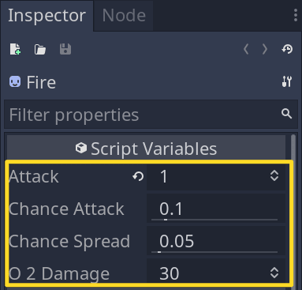

Now we need to update quite a few places because hazards connect with many systems.

## Weapons and hazards

We use a chance-based system for weapons to spawn hazards when they shoot.

This is a minor update because the hazard-spawning logic is implemented elsewhere.

Open the `Weapon.gd` script and add these new variables:

```
# ...
# export (int, 0, 5) var attack := 2
export (float, 0, 1) var chance_fire := 0.0
export (float, 0, 1) var chance_breach := 0.0
```

That’s it for the parent class.

What’s left is to add these parameters in the `params` dictionary.

Go to the `WeaponLaser.gd` script and replace the `params` declaration in `fire()` with:

```
func fire() -> void:
    # ...
    # line.visible = true
    var params := {
        "duration": timer.wait_time,
        "attack": attack,
        "chance_fire": chance_fire,
        "chance_breach": chance_breach
    }
```

Now do the same in `WeaponProjectile.gd`:

```
func fire() -> void:
    # ...
    # projectile.linear_velocity =
    # projectile.linear_velocity.rotated(global_rotation)
    var params := {
        "physics_layer": _physics_layer,
        "target_position": target_position,
        "attack": attack,
        "chance_fire": chance_fire,
        "chance_breach": chance_breach
    }
```

The cool thing about this is that we already set up the pipeline to send the `params` message from one viewport to the other. Making updating the weapons trivial.

Since these are export variables, remember to set them in the *Inspector* when adding them to the ships. Otherwise, the default chance to spawn hazards is set to `0`.

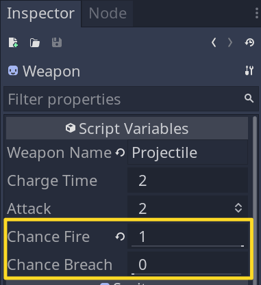

## Unit hitpoints

We want the units to be affected by the hazards.

Open the *Unit* scene and update the tree with these new nodes:

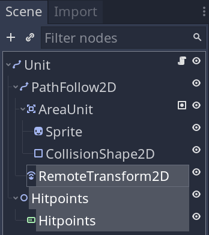

Unlike the

[figure not shown]

`Sprite` representing the unit in the game world, we want the *Hitpoint ProgressBar* to follow the path without rotating.

To achieve this, I opted for a

[figure not shown]

`RemoteTransform2D` node. The problem is that a

[figure not shown]

`RemoteTransform2D` can’t be used directly with

[figure not shown]

`Control` nodes. I used the workaround of placing the

[figure not shown]

`ProgressBar` under a

[figure not shown]

`Node2D` with the same name.

Let’s setup the new nodes.

Select the

[figure not shown]

`RemoteTransform2D` and assign the *Hitpoints Node2D* node to *Remote Path*. Make sure to uncheck *Update -> Rotation*.

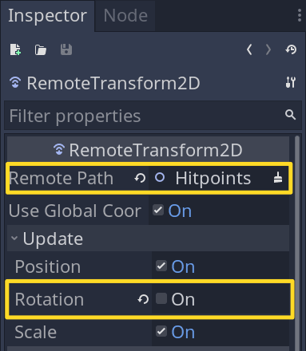

Select the

[figure not shown]

`ProgressBar`, we don’t need the text value visible so let’s start by setting the following properties:

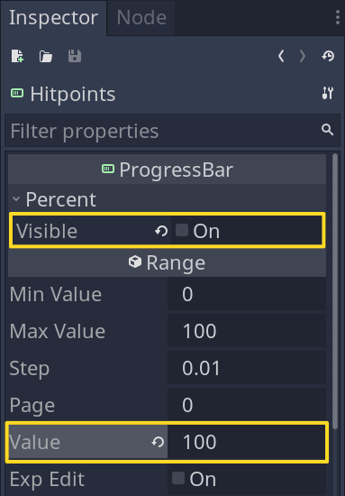

I fixed the

[figure not shown]

`ProgressBar`’s *Range -> Value* property to `100`. The default `[0, 100]` range is fine for the *Unit*’s health.

As a challenge consider exporting the health range like we did with the *Room* scene when coding its `size` that we connected with the size of the

[figure not shown]

`CollisionShape2D` child node.

Now to set the size and position of the

[figure not shown]

`ProgressBar`:

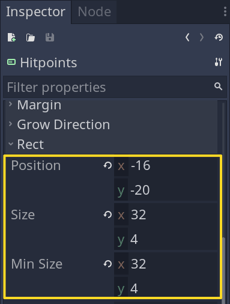

Finally, assign the *UnitHitpoints*.tres assets to *Custom Styles -> Fg* and *Bg* properties to unify the looks:

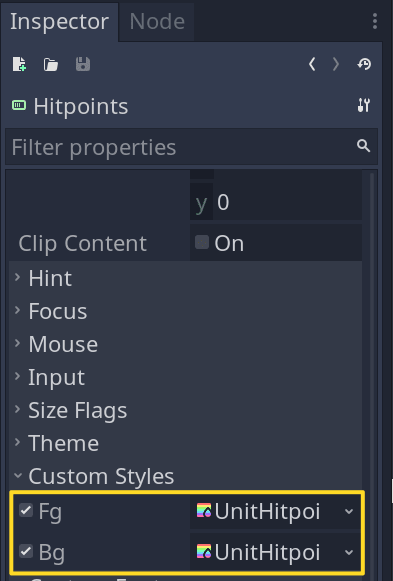

You should get the following result:

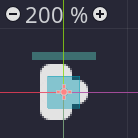

### Coding unit hitpoints

Now that we added the *Hitpoints* visually, we have to update the code. Open the `Unit.gd` script, and lets start at the top with the `died` signal:

```
## Remember that we keep track of units in `ShipTemplate` with the `_slots`
## dictionary. We pass `self` when emitting the signal to erase it from
## `_slots`.
signal died(unit)

# const COLORS := {"default": Color("323e4f"), "selected": Color("3ca370")}
# ...
```

Now we can add these new variables:

```
# ...
# export var speed := 150

## `attack` is the "force" for damaging the hazards.
export var attack := 15
export var o2_damage := 10
```

Next, let’s add a reference to the *Hitpoints* node:

```
# ...
# onready var area_unit: Area2D = $PathFollow2D/AreaUnit
onready var hitpoints: ProgressBar = $Hitpoints/Hitpoints
```

Finally add the `take_damage()` function to apply damage and check for hitpoints status:

```
func take_damage(other_attack: int) -> void:
    hitpoints.value -= other_attack
    if hitpoints.value <= 0:
        queue_free()
        emit_signal("died", self)
```

We’re done with the base *Unit* class, but we have to update *UnitPlayer* to account for the UI attached on the player side.

Open `UnitPlayer.gd` if you haven’t done so and add this new line at the end of `setup()`:

```
 func setup(ui_unit: ColorRect) -> void:
    _ui_unit_feedback = ui_unit.get_node("Feedback")
    ui_unit.get_node("Icon").modulate = COLORS.default
    ui_unit.connect("gui_input", self, "_on_UIUnit_gui_input")
+   connect("tree_exited", ui_unit, "queue_free")
```

We still have a few other places to update before tackling the bulk of the logic in *ShipTemplate*.

## Cheking rooms through doors

Since we plan to deplete oxygen from rooms with hull breaches and affect the other rooms if the doors are open, we’ll keep track of which doors connect which rooms.

Open the `Door.gd` script and declare a `rooms` array:

```
# ...
# var is_open := false setget set_is_open
var rooms := []
```

We add rooms to the array in the `_on_area_entered_exited()` callback function:

```
func _on_area_entered_exited(area: Area2D, has_entered: bool) -> void:
    # ...
                # timer.start()

    elif area.is_in_group("room") and has_entered:
        rooms.push_back(area)
```

We can use the rooms array in *ShipTemplate* when calculating the oxygen depletion rate.

Since we’re on the topic of oxygen depletion, we need to add new player feedback for tracking oxygen dropping down.

But before moving to the *Room* script, let’s add our last utility function.

## Integer random Vector2 in a rectangle

Open the `Utils.gd` script, we are adding a helper function that returns a random position defined by a rectangle.

It’s just like `randvf_range()`, except for integer values, because we want to use it directly with the *Tilemap* coordinates:

```
static func randvi_range(_rng: RandomNumberGenerator, top_left: Vector2, bottom_right: Vector2) -> Vector2:
    var x := _rng.randi_range(top_left.x, bottom_right.x)
    var y := _rng.randi_range(top_left.y, bottom_right.y)
    return Vector2(x, y)
```

Now we’re ready to move on to updating the *Room* scene.

## Room oxygen

Open the *Room* scene. We have to add a new node to our tree:

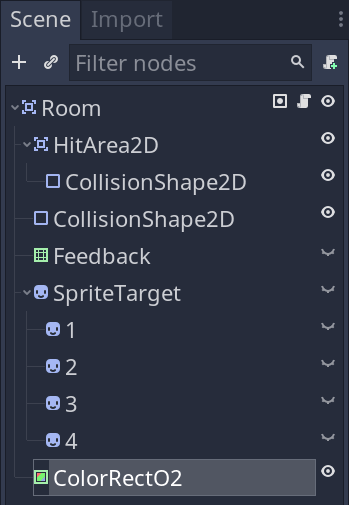

Since this is a

[figure not shown]

`ColorRect` control node, we’ll work directly with its

[figure not shown]

`Color` property.

We’ll have it go from fully transparent when the *Room* has `100`% oxygen to `50`% transparent when the *Room* has `0`% oxygen, so the intensity of the color isn’t too jarring.

Select the *ColorRectO2* node and change these properties:

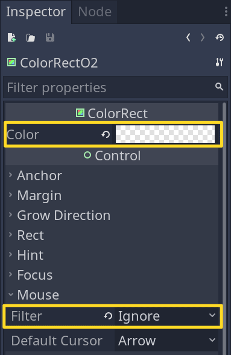

[figure not shown]

We also set *Filter* to *Ignore* so that mouse hovering over rooms still works.

We handle the rest of the setup from code.

Without color transparency, you should get the following result:

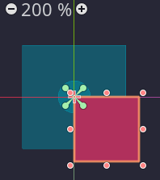

### Tracking room oxygen in code

Since oxygen is restricted to each room, we need to track which units are in which rooms to affect them properly when oxygen depletion occurs.

Open the `Room.gd` script, and let’s start at the top by introducing a few new variables:

```
var units := {}
var o2 := 100 setget set_o2

# var _target_index := -1
# ...
```

And the reference to the new node:

```
# ...
# onready var hit_area: Area2D = $HitArea2D
onready var color_rect_o2: ColorRect = $ColorRectO2
```

Since we already calculated the position and size for the other feedback rectangle, we’ll use those values to set up `color_rect_o2`:

```
func setup(tilemap: TileMap) -> void:
    # ...
    # feedback.rect_size = 2 * collision_shape.shape.extents

    color_rect_o2.rect_position = feedback.rect_position
    color_rect_o2.rect_size = feedback.rect_size
```

We want to check for units moving in and out of rooms so we update the `_on_area_entered()` function to `_on_area_entered_exited()`, using the same strategy as `_on_mouse_entered_exited()` with a boolean bound parameter.

```
 func _ready() -> void:
    connect("mouse_entered", self, "_on_mouse_entered_exited", [true])
    connect("mouse_exited", self, "_on_mouse_entered_exited", [false])
-   connect("area_entered", self, "_on_area_entered")
+ connect("area_entered", self, "_on_area_entered_exited", [true])
+    connect("area_exited", self, "_on_area_entered_exited", [false])
  connect("input_event", self, "_on_input_event")
```

And now, for the function name and sigunature:

```
-func _on_area_entered(area: Area2D) -> void:
+func _on_area_entered_exited(area: Area2D, has_entered: bool) -> void:
```

At the end of it, add this new code:

```
func _on_area_entered_exited(area: Area2D, has_entered: bool) -> void:
    # ...
        # _entrances[entrance] = null

    elif area.is_in_group("unit"):
        if has_entered:
            units[area.owner] = null
        else:
            units.erase(area.owner)
```

We’re keeping track of units with a dictionary, like always. Except here, we use a reference to the *Unit* node as keys.

Let’s now add the random position generator to pick random places to spawn hazards when the weapons fire:

```
func randvi() -> Vector2:
    var offset := Utils.randvi_range(_rng, _top_left, _bottom_right - Vector2.ONE)
    offset = _tilemap.map_to_world(offset) + _tilemap.cell_size / 2
    return offset
```

This is where we use `Utils.randvi_range()` to get a random *Tilemap* cell position, converted back to a pixel position because the hazards aren’t tiles.

And the last function that completes the `Room.gd` script is the oxygen’s setter function:

```
func set_o2(value: int) -> void:
    o2 = clamp(value, 0, 100)
    color_rect_o2.color.a = lerp(0.5, 0, o2 / 100.0)
```

We use `lerp()` by mapping the `o2` value from the `[0, 100]` interval to the [`0.5`, `0.0`] interval, in that order, to update the *ColorRectO2* transparency.

We’re done with the *Room* code and are left with updating the *ShipTemplate* scene.

## The main hazards logic

Open the *ShipTemplate* scene file. We have to add one more node to the scene tree to group the hazards as we add them to the ship.

The location of the *Hazards* node matters because it has to be in front of some nodes but not others.

We also add a timer node and rename it to *TimerHazards*. This timer operates as the clock making hazards “take action”, be it inflicting damage to units, taking damage, or depleting oxygen for hull breaches.

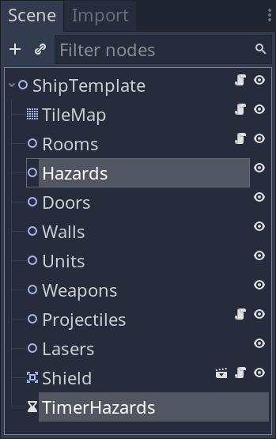

Select the *TimerHazards* node and set *Wait Time* to `0.5`, and turn on *Autostart*.

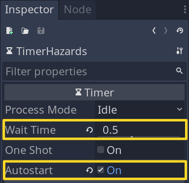

The *Wait Time* is a property you might want to play with until it feels right because it works in conjunction with the chance-based system we use for hazards.

We’re ready to code the *Hazards* node. Attach a script to it with the following content:

```
extends Node2D

## We use the same "trick" with a dictionary for holding `Hazard` positions.
var _slots := {}


func _on_Hazard_tree_exited(hazard_position: Vector2) -> void:
    _slots.erase(hazard_position)


func add(hazard_scene: PackedScene, offset: Vector2) -> Node:
    var out: Node = null

    # We don't want to add hazards that overlap, that's where `_slots` comes in.
    if not offset in _slots:
        var hazard := hazard_scene.instance()
        hazard.position = offset
        hazard.connect("tree_exited", self, "_on_Hazard_tree_exited", [hazard.position])
        add_child(hazard)

        # In case we get a `Hazard` of type `Fire` we move it before `Breach`
        # nodes in the tree. That's because we'll have units always deal with
        # hazards in their tree order and it makes sense for them to first
        # extinguish fires.
        if hazard is Fire:
            var index := 0
            for child in get_children():
                if child is Fire:
                    index += 1
                else:
                    break
            move_child(hazard, index)
        _slots[hazard.position] = null
        out = hazard
    return out
```

The way we add new *Hazard* nodes as children is with the `add()` function.

This is a helper function used by the `ShipTemplate.gd` script. Open it and let’s start from the top:

```
# ...
# const AttackLabel := preload("Weapons/AttackLabel.tscn")

## I attched an `Scene` at the end because `Breach` and `Fire` are already used as
## class names.
const BreachScene := preload("Hazards/Breach.tscn")
const FireScene := preload("Hazards/Fire.tscn")
```

Let’s continue with the new export variables:

```
# ...
# export (int, 0, 30) var hitpoints := 30

## I use the same threshold value to check when to apply damage to `Fire` and
## `Unit` though you might want to move this property in the respective classes.
export (int, 0, 100) var o2_asphyxiation := 10

## The amount of oxygen we replenish every `TimerHazards` tick.
export (int, 0, 10) var o2_replenish := 2
```

And we need to add a `RandomNumberGenerator`, for hazard genration.

```
# ...
# var _slots := {}
var _rng := RandomNumberGenerator.new()
```

Then the missing node references:

```
# ...
# onready var shield: Area2D = $Shield
onready var hazards: Node2D = $Hazards
onready var timer_hazards: Timer = $TimerHazards
```

We need to initialize the `RandomNumberGenerator` and set a few new connections in the `_ready_not_editor_hint()` function:

```
func _ready_not_editor_hint() -> void:
    timer_hazards.connect("timeout", self, "_on_TimerHazards_timeout")
    _rng.randomize()

    # for unit in units.get_children():
        unit.connect("died", self, "_on_Unit_died")
        # for door in doors.get_children():
    # ...
```

Before moving on to the callback functions for these signals, let’s update a few other places.

We introduce a more generic `_handle_attack()` function that calls `_take_damage()`.

Remember that we updated `params` on both *WeaponProjectile* and *WeaponLaser*. This is where we use those chance parameters.

```
func _handle_attack(params: Dictionary, room: Room) -> void:
    if _rng.randf() < params.chance_fire:
        var fire: Fire = hazards.add(FireScene room.randvi())

        # Hazards.add() can fail so we need to check if we acctually have a Fire
        # to work with before connecting its signals.
        if fire != null:
            # Remember that the `attacked` signal sends two parameters when
            # emitted: the attack value and the `Fire` position. Thus, we can
            # connect it directly to `_take_damage()`.
            fire.connect("attacked", self, "_take_damage")
            fire.connect("spread", self, "_on_Fire_spread")


    if _rng.randf() < params.chance_breach:
        hazards.add(BreachScene, room.randvi())

    _take_damage(params.attack, room.position)
```

We now need to replace the `_take_damage()` calls with our new and improved replacement - the `_handle_attack()` function:

```
 func _on_RoomHitArea2D_body_entered(body: RigidBody2D, room: Room) -> void:
    if not room.position.is_equal_approx(body.params.target_position):
        return

    body.queue_free()
-   _take_damage(body.params.attack, room.position)
+ _handle_attack(body.params, room)


 func _on_RoomArea2D_area_entered(area: Area2D, room: Room) -> void:
    if area.is_in_group("laser"):
-       _take_damage(body.params.attack, room.position)
+     _handle_attack(area.params, room)
```

We add one more helper function called `_get_neighbor_position()` for getting a random valid *Tilemap* neighboring position based on the input location. We return the position in game-world coordinates since we use it to place the hazards.

```
func _get_neighbor_position(at: Vector2) -> Vector2:
    var neighbors := []
    var point1 := tilemap.world_to_map(at)
    for offset in Utils.DIRECTIONS:
        var point2: Vector2 = point1 + offset
        if tilemap.get_cellv(point2) != tilemap.INVALID_CELL:
            neighbors.push_back(tilemap.map_to_world(point2) + 0.5 * tilemap.cell_size)

    # Pick one of the valid places at random. This always succeeds because every
    # tile has at least one neighboring tile in our design.
    var index := _rng.randi_range(0, neighbors.size() - 1)
    return neighbors[index]
```

let’s move on to the function callbacks:

```
func _on_Unit_died(unit: Unit) -> void:
    Utils.erase_value(_slots, unit)
    for room in rooms.get_children():
        room.units.erase(unit)


func _on_Fire_spread(fire_position: Vector2) -> void:
    var neighbor_position: Vector2 = _get_neighbor_position(fire_position)
    var fire: Fire = hazards.add(FireScene neighbor_position)
    if fire != null:
        fire.connect("attacked", self, "_take_damage")
        fire.connect("spread", self, "_on_Fire_spread")


func _on_TimerHazards_timeout() -> void:
    _hazards_breach()
    _hazards_units()
    _hazards_o2()
```

We’re left with implementing the three `_hazards_*()` functions. Let’s look at them from top to bottom as they become increasingly complex.

```
func _hazards_breach() -> void:
    for hazard in hazards.get_children():
        # Skip `Fire`.
        if hazard is Fire:
            continue

        for room in rooms.get_children():
            # Check if `room` has this particular `hazard`. If yes, then apply
            # oxygen depletion.
            if room.has_point(tilemap.world_to_map(hazard.position)):
                room.o2 -= hazard.attack
```

Next, we have the hazards and units interaction:

```
func _hazards_units() -> void:
    for room in rooms.get_children():
        # We want only the top most `Hazard` to take damage from units to deal
        # with them in order.
        var hazard_was_attacked := false
        for hazard in hazards.get_children():
            if room.has_point(tilemap.world_to_map(hazard.position)):
                for unit in room.units:
                    # As an extra, if the `Hazard` is `Fire` type, then it also
                    # inflicts damage to the units in this room.
                    if hazard is Fire:
                        unit.take_damage(hazard.attack)

                    if not hazard_was_attacked:
                        hazard.take_damage(unit.attack)
                        hazard_was_attacked = true

                # Furthermore, all `Fire` hazards take damage if we have oxygen
                # depletion.
                if hazard is Fire and room.o2 < o2_asphyxiation:
                    hazard.take_damage(hazard.o2_damage)

        # Finally, apply the oxygen check for units.
        for unit in room.units:
            if room.o2 < o2_asphyxiation:
                unit.take_damage(unit.o2_damage)
```

Our last function deals with the mechanic of spreading oxygen depletion through the ship.

We don’t implement any advanced physics-based model to transfer fluid from one to another. I tried to simplify the process to its minimum.

The strategy is to reach an equilibrium of oxygen quantity between every two *Room* pairs connected through a *Door*.

If the door is shut, we skip the calculation.

```
func _hazards_o2() -> void:
    # Rooms are keys and oxygen amounts are values.
    var o2_associations := {}

    # This holds the number of rooms we traverse each time. For example, we
    # could have two doors connected to the same room, then `room_associations`
    # will have a value of `2` for that `Room` key.
    var room_associations := {}

    for door in doors.get_children():
        if not door.is_open:
            continue

        # We'll calculate the mean value for every two `Room` pairs. This is the
        # target value for equilibrium.
        var o2_mean := 0.0
        for room in door.rooms:
            o2_mean += room.o2

            # We also record how many times we traverse the same `Room`.
            room_associations[room] = room_associations.get(room, 0) + 1

        # Finish calculating the mean by dividing with the size of the room's
        # array.
        o2_mean /= door.rooms.size()

        # For each `Room`, we add the mean value that the `Room` participates
        # in. The same `Room` can be connected with multiple rooms so we need to
        # account for more than one `o2_mean` value. That's why we need
        # `room_associations[room]`.
        for room in door.rooms:
            o2_associations[room] = o2_associations.get(room, 0) + o2_mean

    # Traverse overa all rooms because we need all of them to replenish lost
    # oxygen.
    for room in rooms.get_children():
        if room in o2_associations:
            # Divide by the number of times this `Room` was used in the
            # `o2_mean` calculation.
            o2_associations[room] /= room_associations[room]

            # To register oxygen loss, we don't jump directly to the equilibrium
            # point. Instead, we gradually move towards it by using
            # interpolation.
            # The `0.5` step is arbitrary and possibly needs adjusting.
            room.o2 = lerp(room.o2, o2_associations[room], 0.5)

        # Finally, as our last action, we replenish a portion of the oxygen. We
        # assume that the ship has a working oxygen mechanism at all times.
        room.o2 += o2_replenish
```

This was a fairly complex topic, but we did it!

We implemented weapons to devastate opposing ships with hazards on top of their regular attacks.

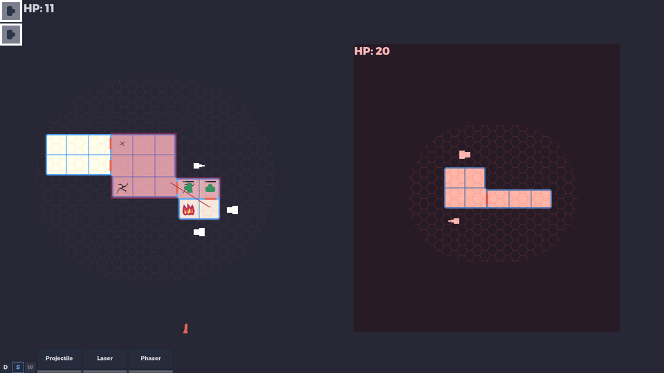

## Conclusion

We covered a vital mechanic of our demo in this lesson - destroying ships with hazards caused randomly by weapons.

We saw how to create a hierarchy for the *Hazard* nodes and build from simple static breaches to the more complex fires with animation and spreading through the ship.

We covered how to add randomness into our game by having chance-based parameters on weapons and the *Fire* spreading mechanic.

We also saw how to break down the oxygen depletion mechanic, which can be a reasonably complex topic on its own.

At this point, it’s up to you to decide where to take these implementations. They’re not perfect by any means.

I hinted at some of the modifications you might want to make:

- Units could be affected differently by oxygen depletion compared to fires.
- Fires could be affected by door open or closed status.

You can probably think of many more. For example, breaches deplete the oxygen at the same rate, even if they’re partially repaired. Maybe that’s something that needs improvement.

In the next lesson, we’ll go over *Room* types and modifiers. If rooms are specialized, they’ll get a

[figure not shown]

`Sprite` to distinguish them.

When we station units in these rooms, they’ll change how we handle some game mechanics.

For example, if we station them in the helm *Room*, the ship will have a chance to evade incoming projectiles. We’ll cover many more types of rooms.

It’s exciting stuff!

It’s also our last lesson about mechanics. After this, we have one more to cover - adding a few visual effects to make our demo pop, and we’ll be done with this course!

## Code reference

`res://TacticalSpaceCombat/Ship/Hazards/Hazard.gd`:

```
class_name Hazard
extends Sprite

const THRESHOLD := {"medium": 70, "low": 30}

export (int) var attack := 10

var _hitpoints := 100 setget _set_hitpoints


func take_damage(value: int) -> void:
    _set_hitpoints(_hitpoints - value)


func _set_hitpoints(value: int) -> void:
    _hitpoints = value
    if _hitpoints <= 0:
        queue_free()
```

`res://TacticalSpaceCombat/Ship/Hazards/Breach.gd`:

```
class_name Breach
extends Hazard


func _set_hitpoints(value: int) -> void:
    ._set_hitpoints(value)

    if THRESHOLD.low <= _hitpoints and _hitpoints < THRESHOLD.medium:
        scale = 0.75 * Vector2.ONE
    elif _hitpoints < THRESHOLD.low:
        scale = 0.5 * Vector2.ONE
```

`res://TacticalSpaceCombat/Ship/Hazards/Fire.gd`:

```
class_name Fire
extends Hazard

signal attacked(attack, position)
signal spread(position)

export (float, 0.0, 1.0) var chance_attack := 0.1
export (float, 0.0, 1.0) var chance_spread := 0.05
export (int, 0, 100) var o2_damage := 30

var _rng := RandomNumberGenerator.new()

onready var timer: Timer = $Timer
onready var animation_player: AnimationPlayer = $AnimationPlayer


func _ready() -> void:
    timer.connect("timeout", self, "_on_Timer_timeout")
    _rng.randomize()


func _on_Timer_timeout() -> void:
    if _rng.randf() < chance_attack:
        emit_signal("attacked", attack, position)

    if _rng.randf() < chance_spread:
        emit_signal("spread", position)


func _set_hitpoints(value: int) -> void:
    ._set_hitpoints(value)

    var animation := "high"
    if _hitpoints < THRESHOLD.low:
        animation = "low"
    elif _hitpoints < THRESHOLD.medium:
        animation = "medium"

    if animation_player.current_animation != animation:
        animation_player.play(animation)
```

`res://TacticalSpaceCombat/Ship/Weapons/Weapon.gd`:

```
class_name Weapon
extends Sprite

const MIN_CHARGE := 0
const MAX_CHARGE := 100

export var weapon_name := ""
export var charge_time := 2.0
export (int, 0, 5) var attack := 2
export (float, 0, 1) var chance_fire := 0.0
export (float, 0, 1) var chance_breach := 0.0

var is_charging := false setget set_is_charging

var _charge := MIN_CHARGE

onready var tween: Tween = $Tween


func _ready() -> void:
    tween.connect("tween_all_completed", self, "set_is_charging", [false])
    self.is_charging = true


func fire() -> void:
    pass


func set_is_charging(value: bool) -> void:
    is_charging = value
    if is_charging:
        tween.interpolate_property(self, "_charge", MIN_CHARGE, MAX_CHARGE, charge_time)
        tween.start()
    fire()
```

`res://TacticalSpaceCombat/Ship/Weapons/WeaponProjectile.gd`:

```
tool
extends Weapon

signal fired
signal projectile_exited(params)

const Projectile := preload("Projectile.tscn")

var target_position := Vector2.INF

var _physics_layer := -1


func setup(physics_layer: int) -> void:
    _physics_layer = physics_layer


func _get_configuration_warning() -> String:
    var parent := get_parent()
    var is_verified := parent != null and parent is ControllerAIProjectile or parent is ControllerPlayerProjectile
    return "" if is_verified else "WeaponProjectile needs to be a parent of Controller*Projectile"


func fire() -> void:
    if not can_fire():
        return

    self.is_charging = true
    var projectile: RigidBody2D = Projectile.instance()
    projectile.linear_velocity = projectile.linear_velocity.rotated(global_rotation)
    var params := {
        "physics_layer": _physics_layer,
        "target_position": target_position,
        "attack": attack,
        "chance_fire": chance_fire,
        "chance_breach": chance_breach
    }
    projectile.connect("tree_exited", self, "emit_signal", ["projectile_exited", params])
    add_child(projectile)
    emit_signal("fired")


func can_fire() -> bool:
    return not is_charging and target_position != Vector2.INF
```

`res://TacticalSpaceCombat/Ship/Weapons/WeaponLaser.gd`:

```
tool
extends Weapon

signal fire_started(params)
signal fire_stopped

export (int, 0, 250) var targeting_length := 140
export var color := Color("b0305c")

var has_targeted := false

onready var timer: Timer = $Timer
onready var line: Line2D = $Line2D


func _ready() -> void:
    if Engine.editor_hint:
        return

    timer.connect("timeout", self, "emit_signal", ["fire_stopped"])
    timer.connect("timeout", self, "set_is_charging", [true])
    timer.connect("timeout", line, "set_visible", [false])
    line.default_color = color


func _get_configuration_warning() -> String:
    var parent := get_parent()
    var is_verified := parent != null and parent is ControllerAILaser or parent is ControllerPlayerLaser
    return "" if is_verified else "WeaponLaser needs to be a parent of Controller*Laser"


func fire() -> void:
    if not can_fire():
        return

    timer.start()
    has_targeted = false
    line.visible = true
    var params := {
        "duration": timer.wait_time,
        "attack": attack,
        "chance_fire": chance_fire,
        "chance_breach": chance_breach
    }
    emit_signal("fire_started", params)


func can_fire() -> bool:
    return not is_charging and has_targeted
```

`res://TacticalSpaceCombat/Ship/Units/Unit.gd`:

```
class_name Unit
extends Path2D

signal died(unit)

const COLORS := {"default": Color("323e4f"), "selected": Color("3ca370")}

export var speed := 150
export var attack := 15
export var o2_damage := 10

var is_walking: bool setget set_is_walking

onready var path_follow: PathFollow2D = $PathFollow2D
onready var area_unit: Area2D = $PathFollow2D/AreaUnit
onready var hitpoints: ProgressBar = $Hitpoints/Hitpoints


func _ready() -> void:
    area_unit.connect("area_entered", self, "_on_AreaUnit_area_entered")
    area_unit.modulate = COLORS.default
    self.is_walking = false


func _on_AreaUnit_area_entered(area: Area2D) -> void:
    if area.is_in_group("door") and not area.is_open:
        self.is_walking = false


func _process(delta: float) -> void:
    path_follow.offset += speed * delta
    if path_follow.offset >= curve.get_baked_length():
        self.is_walking = false


func walk(path: Curve2D) -> void:
    if path.get_point_count() == 0:
        return

    curve = path
    curve.add_point(path_follow.position, Vector2.ZERO, Vector2.ZERO, 0)
    path_follow.offset = 0
    self.is_walking = true


func take_damage(other_attack: int) -> void:
    hitpoints.value -= other_attack
    if hitpoints.value <= 0:
        queue_free()
        emit_signal("died", self)


func set_is_walking(value: bool) -> void:
    is_walking = value
    set_process(is_walking)
```

`res://TacticalSpaceCombat/Ship/Units/UnitPlayer.gd`:

```
extends Unit

var is_selected: bool setget set_is_selected

var _ui_unit_feedback: NinePatchRect

onready var area_select: Area2D = $PathFollow2D/AreaSelect


func setup(ui_unit: ColorRect) -> void:
    _ui_unit_feedback = ui_unit.get_node("Feedback")
    ui_unit.get_node("Icon").modulate = COLORS.default
    ui_unit.connect("gui_input", self, "_on_UIUnit_gui_input")
    connect("tree_exited", ui_unit, "queue_free")


func _ready() -> void:
    self.is_selected = false


func _on_UIUnit_gui_input(event: InputEvent) -> void:
    if event.is_action_pressed("left_click"):
        self.is_selected = true


func set_is_selected(value: bool) -> void:
    var group := "selected-unit"

    is_selected = value
    if is_selected:
        area_unit.modulate = COLORS.selected
        add_to_group(group)
    else:
        area_unit.modulate = COLORS.default
        if is_in_group(group):
            remove_from_group(group)

    if _ui_unit_feedback != null:
        _ui_unit_feedback.visible = is_selected
```

`res://TacticalSpaceCombat/Ship/Rooms/Door.gd`:

```
extends Area2D

signal opened

var is_open := false setget set_is_open
var rooms := []

var _units := 0

onready var sprite: Sprite = $Sprite
onready var timer: Timer = $Timer


func _ready() -> void:
    connect("area_entered", self, "_on_area_entered_exited", [true])
    connect("area_exited", self, "_on_area_entered_exited", [false])
    timer.connect("timeout", self, "set_is_open", [true])


func _on_area_entered_exited(area: Area2D, has_entered: bool) -> void:
    if area.is_in_group("unit"):
        _units += 1 if has_entered else -1

        match [_units, has_entered]:
            [0, false]:
                self.is_open = false

            [1, true]:
                timer.start()

    elif area.is_in_group("room") and has_entered:
        rooms.push_back(area)


func set_is_open(value: bool) -> void:
    is_open = value
    if is_open:
        sprite.frame = 1
        emit_signal("opened")
    else:
        sprite.frame = 0
```

`res://TacticalSpaceCombat/Utils.gd`:

```
class_name Utils

const DIRECTIONS := [
    Vector2.UP,
    Vector2.RIGHT + Vector2.UP,
    Vector2.RIGHT,
    Vector2.RIGHT + Vector2.DOWN,
    Vector2.DOWN,
    Vector2.LEFT + Vector2.DOWN,
    Vector2.LEFT,
    Vector2.LEFT + Vector2.UP
]

static func xy_to_index(width: int, offset: Vector2) -> int:
    return int(offset.x + width * offset.y)

static func index_to_xy(width: int, index: int) -> Vector2:
    return Vector2(index % width, index / width)

static func erase_value(dict: Dictionary, value) -> bool:
    var out := false
    for key in dict:
        if dict[key] == value:
            out = dict.erase(key)
    return out

static func randvf_circle(_rng: RandomNumberGenerator, radius: float) -> Vector2:
    return (radius * Vector2.RIGHT).rotated(_rng.randf_range(0, TAU))

static func randvf_range(_rng: RandomNumberGenerator, top_left: Vector2, bottom_right: Vector2) -> Vector2:
    var x: float = lerp(top_left.x, bottom_right.x, _rng.randf())
    var y: float = lerp(top_left.y, bottom_right.y, _rng.randf())
    return Vector2(x, y)

static func randvi_range(_rng: RandomNumberGenerator, top_left: Vector2, bottom_right: Vector2) -> Vector2:
    var x := _rng.randi_range(top_left.x, bottom_right.x)
    var y := _rng.randi_range(top_left.y, bottom_right.y)
    return Vector2(x, y)
```

`res://TacticalSpaceCombat/Ship/Rooms/Room.gd`:

```
tool
class_name Room
extends Area2D

signal targeted(msg)

export var size := Vector2.ONE setget set_size

var units := {}
var o2 := 100 setget set_o2

var _target_index := -1

var _rng := RandomNumberGenerator.new()
var _entrances := {}
var _area := 0
var _top_left := Vector2.ZERO
var _bottom_right := Vector2.ZERO

var _iter_index := 0

var _tilemap: TileMap = null

onready var collision_shape: CollisionShape2D = $CollisionShape2D
onready var feedback: NinePatchRect = $Feedback
onready var sprite_target: Sprite = $SpriteTarget
onready var hit_area: Area2D = $HitArea2D
onready var color_rect_o2: ColorRect = $ColorRectO2


func setup(tilemap: TileMap) -> void:
    _tilemap = tilemap
    _setup_extents()

    if not Engine.editor_hint:
        hit_area.collision_mask = (
            Global.Layers.SHIPPLAYER
            if owner.is_in_group("player")
            else Global.Layers.SHIPAI
        )

    _area = size.x * size.y
    _top_left = _tilemap.world_to_map(position - collision_shape.shape.extents)
    _bottom_right = _top_left + size

    feedback.rect_position -= collision_shape.shape.extents
    feedback.rect_size = 2 * collision_shape.shape.extents

    color_rect_o2.rect_position = feedback.rect_position
    color_rect_o2.rect_size = feedback.rect_size


func _setup_extents() -> void:
    if _tilemap != null:
        collision_shape.shape.extents = 0.5 * _tilemap.map_to_world(size)


func _ready() -> void:
    connect("mouse_entered", self, "_on_mouse_entered_exited", [true])
    connect("mouse_exited", self, "_on_mouse_entered_exited", [false])
    connect("area_entered", self, "_on_area_entered_exited", [true])
    connect("area_exited", self, "_on_area_entered_exited", [false])
    connect("input_event", self, "_on_input_event")
    _rng.randomize()


func _on_input_event(_v: Viewport, event: InputEvent, _s: int) -> void:
    if (
        event.is_action_pressed("left_click")
        and Input.get_current_cursor_shape() == Input.CURSOR_CROSS
        and _target_index != -1
    ):
        sprite_target.visible = true
        sprite_target.get_child(_target_index).visible = true
        emit_signal(
            "targeted",
            {
                "type": Controller.Type.PROJECTILE,
                "index": _target_index,
                "target_position": position
            }
        )
        _target_index = -1


func _on_mouse_entered_exited(has_entered: bool) -> void:
    feedback.visible = has_entered
    var group := "selected-room"
    if has_entered:
        add_to_group(group)
    elif is_in_group(group):
        remove_from_group(group)


func _on_area_entered_exited(area: Area2D, has_entered: bool) -> void:
    if area.is_in_group("door"):
        var entrance := position - area.position
        entrance = entrance.project(Vector2.DOWN.rotated(area.rotation)).normalized()
        entrance *= 0.5 * _tilemap.cell_size.x
        entrance += area.position
        entrance = _tilemap.world_to_map(entrance)
        _entrances[entrance] = null

    elif area.is_in_group("unit"):
        if has_entered:
            units[area.owner] = null
        else:
            units.erase(area.owner)


func _on_Controller_targeting(msg: Dictionary) -> void:
    _target_index = msg.index
    if _target_index != -1:
        sprite_target.visible = false
        sprite_target.get_child(_target_index).visible = false
        for node in sprite_target.get_children():
            if node.visible:
                sprite_target.visible = true
                break


func randv() -> Vector2:
    var top_left_world := _tilemap.map_to_world(_top_left)
    var bottom_right_world := _tilemap.map_to_world(_bottom_right)
    return Utils.randvf_range(_rng, top_left_world, bottom_right_world)


func randvi() -> Vector2:
    var offset := Utils.randvi_range(_rng, _top_left, _bottom_right - Vector2.ONE)
    offset = _tilemap.map_to_world(offset) + _tilemap.cell_size / 2
    return offset


func has_point(point: Vector2) -> bool:
    return Rect2(_top_left, size).has_point(point)


func set_size(value: Vector2) -> void:
    for axis in [Vector2.AXIS_X, Vector2.AXIS_Y]:
        size[axis] = max(1, value[axis])
    _setup_extents()


func set_o2(value: int) -> void:
    o2 = clamp(value, 0, 100)
    color_rect_o2.color.a = lerp(0.5, 0, o2 / 100.0)


func get_slot(slots: Dictionary, unit: Unit) -> Vector2:
    var out := Vector2.INF
    var entrance := _get_entrance(_tilemap.world_to_map(unit.path_follow.position))

    var valid_positions := []
    for offset in self:
        valid_positions.push_back([offset, offset.distance_to(entrance)])
    valid_positions.sort_custom(self, "sort_by_second_index")

    for data in valid_positions:
        var offset: Vector2 = data[0]
        if not (offset in slots and slots[offset] != unit):
            out = offset
            break
    return out


static func sort_by_second_index(a: Array, b: Array) -> bool:
    return a[1] < b[1]


func _get_entrance(from: Vector2) -> Vector2:
    var out := Vector2.INF
    var distance := INF
    for entrance in _entrances:
        var curve: Curve2D = _tilemap.find_path(from, entrance)
        var length := curve.get_baked_length()
        if distance > length:
            distance = length
            out = entrance
    return out


func _iter_init(_arg) -> bool:
    _iter_index = 0
    return _iter_is_running()


func _iter_next(_arg) -> bool:
    _iter_index += 1
    return _iter_is_running()


func _iter_get(_arg) -> Vector2:
    var offset := Utils.index_to_xy(size.x, _iter_index)
    return _top_left + offset


func _iter_is_running() -> bool:
    return _iter_index < _area
```

`res://TacticalSpaceCombat/Ship/Hazards.gd`:

```
extends Node2D

var _rng := RandomNumberGenerator.new()
var _slots := {}


func _on_Hazard_tree_exited(hazard_position: Vector2) -> void:
    _slots.erase(hazard_position)


func add(hazard_scene: PackedScene, offset: Vector2) -> Node:
    var out: Node = null
    if not offset in _slots:
        var hazard := hazard_scene.instance()
        hazard.position = offset
        hazard.connect("tree_exited", self, "_on_Hazard_tree_exited", [hazard.position])
        add_child(hazard)
        if hazard is Fire:
            var index := 0
            for child in get_children():
                if child is Fire:
                    index += 1
                else:
                    break
            move_child(hazard, index)
        _slots[hazard.position] = null
        out = hazard
    return out
```

`res://TacticalSpaceCombat/Ship/ShipTemplate.gd`:

```
tool
extends Node2D

signal hitpoints_changed(hitpoints, is_player)

const LaserTracker := preload("Weapons/LaserTracker.tscn")
const AttackLabel := preload("Weapons/AttackLabel.tscn")
const BreachScene := preload("Hazards/Breach.tscn")
const FireScene := preload("Hazards/Fire.tscn")

export (int, 0, 30) var hitpoints := 30
export (int, 0, 100) var o2_asphyxiation := 10
export (int, 0, 10) var o2_replenish := 2

var _slots := {}
var _rng := RandomNumberGenerator.new()

onready var tilemap: TileMap = $TileMap
onready var rooms: Node2D = $Rooms
onready var doors: Node2D = $Doors
onready var units: Node2D = $Units
onready var weapons: Node2D = $Weapons
onready var projectiles: Node2D = $Projectiles
onready var lasers: Node2D = $Lasers
onready var shield: Area2D = $Shield
onready var hazards: Node2D = $Hazards
onready var timer_hazards: Timer = $TimerHazards


func _ready() -> void:
    call("_ready_editor_hint" if Engine.editor_hint else "_ready_not_editor_hint")


func _ready_editor_hint() -> void:
    for room in rooms.get_children():
        room.setup(tilemap)


func _ready_not_editor_hint() -> void:
    timer_hazards.connect("timeout", self, "_on_TimerHazards_timeout")
    _rng.randomize()

    for unit in units.get_children():
        unit.connect("died", self, "_on_Unit_died")
        for door in doors.get_children():
            door.connect("opened", unit, "set_is_walking", [true])

        var position_map := tilemap.world_to_map(unit.path_follow.position)
        _slots[position_map] = unit

    for room in rooms.get_children():
        room.connect("area_entered", self, "_on_RoomArea2D_area_entered", [room])
        room.hit_area.connect("body_entered", self, "_on_RoomHitArea2D_body_entered", [room])
        room.setup(tilemap)

        for point in room:
            tilemap.set_cellv(point, 0)

    tilemap.setup(rooms, doors)
    projectiles.setup(rooms.mean_position)
    shield.setup(
        rooms.mean_position,
        Global.Layers.SHIPPLAYER if is_in_group("player") else Global.Layers.SHIPAI
    )


func _get_configuration_warning() -> String:
    var is_verified := (
        is_in_group("player")
        and weapons.get_child_count() <= 4
        or not is_in_group("player")
    )
    return "" if is_verified else "%s can't have more than 4 weapons!" % name


func _unhandled_input(event: InputEvent) -> void:
    if not event.is_action_pressed("right_click"):
        return

    for unit in get_tree().get_nodes_in_group("selected-unit"):
        var point1: Vector2 = tilemap.world_to_map(unit.path_follow.position)
        for room in get_tree().get_nodes_in_group("selected-room"):
            if not room.owner.is_in_group("player"):
                break

            var point2: Vector2 = room.get_slot(_slots, unit)
            if is_inf(point2.x):
                break

            var path: Curve2D = tilemap.find_path(point1, point2)
            Utils.erase_value(_slots, unit)
            _slots[point2] = unit
            unit.walk(path)


func _on_UIDoorsButton_pressed() -> void:
    var has_opened_doors := false
    for door in doors.get_children():
        if door.is_open:
            has_opened_doors = true
            break

    for door in doors.get_children():
        door.is_open = not has_opened_doors


func _on_RoomHitArea2D_body_entered(body: RigidBody2D, room: Room) -> void:
    if not room.position.is_equal_approx(body.params.target_position):
        return

    body.queue_free()
    _handle_attack(body.params, room)


func _on_RoomArea2D_area_entered(area: Area2D, room: Room) -> void:
    if area.is_in_group("laser"):
        _handle_attack(area.params, room)


func _on_Unit_died(unit: Unit) -> void:
    Utils.erase_value(_slots, unit)
    for room in rooms.get_children():
        room.units.erase(unit)


func _on_Fire_spread(fire_position: Vector2) -> void:
    var neighbor_position := _get_neighbor_position(fire_position)
    var fire: Fire = hazards.add(FireScene, neighbor_position)
    if fire != null:
        fire.connect("attacked", self, "_take_damage")
        fire.connect("spread", self, "_on_Fire_spread")


func _on_TimerHazards_timeout() -> void:
    _hazards_breach()
    _hazards_units()
    _hazards_o2()


func _hazards_breach() -> void:
    for hazard in hazards.get_children():
        if hazard is Fire:
            continue

        for room in rooms.get_children():
            if room.has_point(tilemap.world_to_map(hazard.position)):
                room.o2 -= hazard.attack


func _hazards_units() -> void:
    for room in rooms.get_children():
        var hazard_was_attacked := false
        for hazard in hazards.get_children():
            if room.has_point(tilemap.world_to_map(hazard.position)):
                for unit in room.units:
                    if hazard is Fire:
                        unit.take_damage(hazard.attack)

                    if not hazard_was_attacked:
                        hazard.take_damage(unit.attack)
                        hazard_was_attacked = true

                if hazard is Fire and room.o2 < o2_asphyxiation:
                    hazard.take_damage(hazard.o2_damage)

        for unit in room.units:
            if room.o2 < o2_asphyxiation:
                unit.take_damage(unit.o2_damage)


func _hazards_o2() -> void:
    var o2_associations := {}
    var room_associations := {}
    for door in doors.get_children():
        if not door.is_open:
            continue

        var o2_mean := 0.0
        for room in door.rooms:
            o2_mean += room.o2
            room_associations[room] = room_associations.get(room, 0) + 1
        o2_mean /= door.rooms.size()

        for room in door.rooms:
            o2_associations[room] = o2_associations.get(room, 0) + o2_mean

    for room in rooms.get_children():
        if room in o2_associations:
            o2_associations[room] /= room_associations[room]
            room.o2 = lerp(room.o2, o2_associations[room], 0.5)
        room.o2 += o2_replenish


func add_laser_tracker(color: Color) -> Node:
    var laser_tracker := LaserTracker.instance()
    lasers.add_child(laser_tracker)
    laser_tracker.setup(color, rooms, shield)
    return laser_tracker


func _handle_attack(params: Dictionary, room: Room) -> void:
    if _rng.randf() < params.chance_fire:
        var fire: Fire = hazards.add(FireScene, room.randvi())
        if fire != null:
            fire.connect("attacked", self, "_take_damage")
            fire.connect("spread", self, "_on_Fire_spread")


    if _rng.randf() < params.chance_breach:
        hazards.add(BreachScene, room.randvi())

    _take_damage(params.attack, room.position)


func _take_damage(attack: int, object_position: Vector2) -> void:
    var attack_label := AttackLabel.instance()
    attack_label.setup(attack, object_position)
    add_child(attack_label)

    hitpoints -= attack
    hitpoints = max(0, hitpoints)
    emit_signal("hitpoints_changed", hitpoints, is_in_group("player"))


func _get_neighbor_position(at: Vector2) -> Vector2:
    var neighbors := []
    var point1 := tilemap.world_to_map(at)
    for offset in Utils.DIRECTIONS:
        var point2: Vector2 = point1 + offset
        if tilemap.get_cellv(point2) != tilemap.INVALID_CELL:
            neighbors.push_back(tilemap.map_to_world(point2) + 0.5 * tilemap.cell_size)
    var index := _rng.randi_range(0, neighbors.size() - 1)
    return neighbors[index]
```